# Prediction Assignment Writeup

Remko Logemann

February 13, 2019

## Data preperation

Let us start by loading the training and testing datasets and view their dimensions.

```r
training <- read.csv('../pml-training.csv', na.strings = c("","NA"))
testing <- read.csv('../pml-testing.csv', na.strings = c("","NA"))
dim(training)
```

```
## [1] 19622   160
```

```r
dim(testing)
```

```
## [1]  20 160
```

So both the training and test set consist of 160 features. Next step is to clean the dataset, here we choose the simplest approach to just ignore all features with missing values. As the number of features is rather large this might work already sufficiently. Also we remove the first seven columns they have no predictive value.

```r
training <- training[8:length(training)]
training <- training[, colSums(is.na(training)) == 0]

testing <- testing[8:length(testing)]
testing <- testing[, colSums(is.na(testing)) == 0]
```

## Partition data

Next we split the training set into a training (70%) and validation (30%) part in addition to the test set:

```r
PartData <- createDataPartition(training$classe, p=0.7, list=FALSE)
trainingSet <- training[PartData, ]
validationSet <- training[-PartData, ]
```

Next, let us check how the classe are divided in the trainingset:

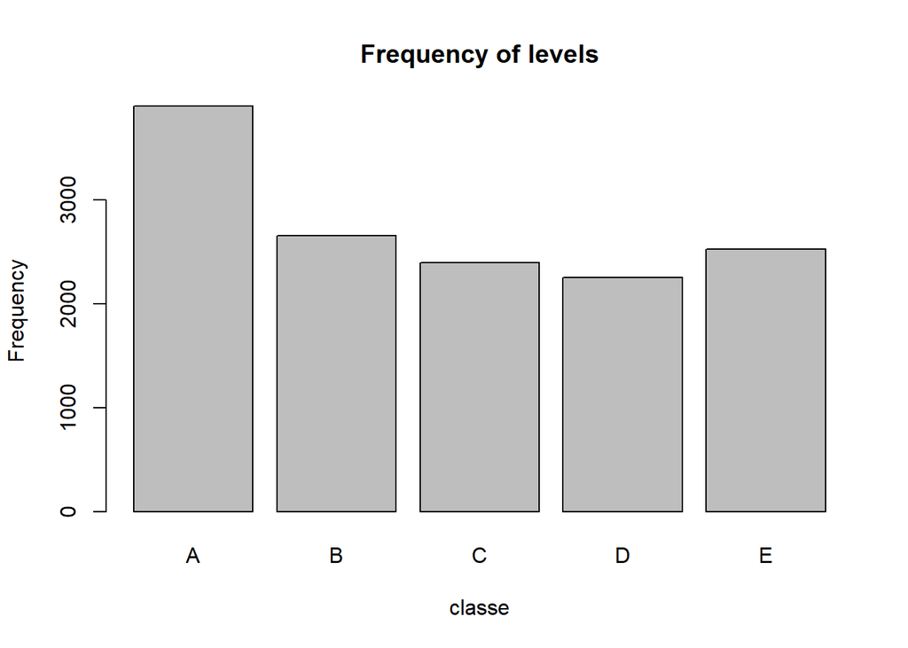

```r
plot(trainingSet$classe, main="Frequency of levels", xlab="classe", ylab="Frequency")
```

The figure above shows that the classe is distributed among the levels in the same order of magnetitude. Therefore no extra effort is required to balance the classe.

## Model training and cross-validation

Next we train our random forest, where we use cross-validation with 4 folds to estimate the in and out-of sample errors later on:

```r
set.seed(1234)
rf <- train(classe ~ ., data = trainingSet, method = "rf", trControl=trainControl(method="cv", number=4))
```

```r
rf$finalModel
```

```
##
## Call:
##  randomForest(x = x, y = y, mtry = param$mtry)
##                Type of random forest: classification
##                      Number of trees: 500
## No. of variables tried at each split: 27
##
##         OOB estimate of  error rate: 0.73%
## Confusion matrix:
##      A    B    C    D    E class.error
## A 3899    4    2    0    1 0.001792115
## B   22 2625   10    1    0 0.012415350
## C    0   12 2379    5    0 0.007095159
## D    0    0   26 2224    2 0.012433393
## E    0    2    5    8 2510 0.005940594
```

```r
print(rf)
```

```
## Random Forest
##
## 13737 samples
##    52 predictor
##     5 classes: 'A', 'B', 'C', 'D', 'E'
##
## No pre-processing
## Resampling: Cross-Validated (4 fold)
## Summary of sample sizes: 10304, 10303, 10301, 10303
## Resampling results across tuning parameters:
##
##   mtry  Accuracy   Kappa
##    2    0.9893722  0.9865541
##   27    0.9897359  0.9870149
##   52    0.9838394  0.9795553
##
## Accuracy was used to select the optimal model using the largest value.
## The final value used for the model was mtry = 27.
```

Hence our in-sample-error is $1.03\%$.

To estimate the out-of-sample error, we use the validation set which is untouched during the model training:

```r
pred_rf <- predict(rf, validationSet)
confusionMatrix(pred_rf, validationSet$classe)
```

```
## Confusion Matrix and Statistics
##
##           Reference
## Prediction    A    B    C    D    E
##          A 1670    8    0    0    0
##          B    2 1128    3    1    1
##          C    2    3 1019    7    1
##          D    0    0    4  956    2
##          E    0    0    0    0 1078
##
## Overall Statistics
##
##                Accuracy : 0.9942
##                  95% CI : (0.9919, 0.996)
##     No Information Rate : 0.2845
##     P-Value [Acc > NIR] : < 2.2e-16
##
##                   Kappa : 0.9927
##  Mcnemar's Test P-Value : NA
##
## Statistics by Class:
##
##                      Class: A Class: B Class: C Class: D Class: E
## Sensitivity            0.9976   0.9903   0.9932   0.9917   0.9963
## Specificity            0.9981   0.9985   0.9973   0.9988   1.0000
## Pos Pred Value         0.9952   0.9938   0.9874   0.9938   1.0000
## Neg Pred Value         0.9990   0.9977   0.9986   0.9984   0.9992
## Prevalence             0.2845   0.1935   0.1743   0.1638   0.1839
## Detection Rate         0.2838   0.1917   0.1732   0.1624   0.1832
## Detection Prevalence   0.2851   0.1929   0.1754   0.1635   0.1832
## Balanced Accuracy      0.9979   0.9944   0.9953   0.9952   0.9982
```

Therefore, our estimation of the out-of-sample error is **$0.58\%$**.

Next, we apply the random forest model to the test set of 20:

```r
predictTest <- predict(rf, testing)

predictTest
```

```
##  [1] B A B A A E D B A A B C B A E E A B B B
## Levels: A B C D E
```